# airline-delay-prediction

## Airline Delay Prediction

### MIGUEL PEREZ CARO

The idea is to receive on-time airline performance data and calculate the departure delay for any scheduled flight. Things to note:

1. 12 months (07.2018 - 06.2019) are for training/validation and 2 months (07.2019 - 08.2019) for testing purposes.
2. Flight is classified as delayed, when it is late 15 minutes or more.
3. DepDelay is the target variable (Difference in minutes between scheduled and actual departure time. Early departures show negative numbers).
4. Scheduled departure time of the flight is the last available moment for doing prediction.
5. For modeling/analysis use a subset of 8 carriers, which are the most common in the dataset.
6. Feel free to use any publicly available information/dataset for feature engineering.
7. Don’t forget about exploratory data analysis (at least 3 questions & answers).

Importing libraries

```python
import os
import glob
import datetime
import numpy as np
import pandas as pd
import seaborn as sns
import tensorflow as tf
from tensorflow import keras
import matplotlib.pyplot as plt
from keras.models import Sequential
from sklearn.pipeline import Pipeline
from keras.layers import Dense, Dropout
from sklearn.linear_model import SGDRegressor
from sklearn.preprocessing import LabelEncoder
from sklearn.tree import DecisionTreeRegressor
from sklearn.preprocessing import StandardScaler
from sklearn.model_selection import GridSearchCV
from sklearn.ensemble import RandomForestRegressor
from sklearn.metrics import r2_score, mean_absolute_error, mean_squared_error

sns.set()
```

Getting the data

```python
# Setting the working directory
data_dir = os.path.join(os.getcwd(), 'Data')
os.chdir(data_dir)
```

```python
# List of the data file names
all_filenames = [i for i in glob.glob('*.{}'.format('csv'))]
```

Further analysis has shown that there are some months which are not included in the dataset. This is going to be checked by collecting the unique dates for each dataset.

```python
# Joining data files
df_raw = pd.DataFrame()
dic_dates = dict()
for i in all_filenames:
    df = pd.read_csv(i)
    df = df.astype({'FL_DATE': 'datetime64'})
    dic_dates[os.path.splitext(i)[0]]=[list(set(df['FL_DATE'])),df.shape[0]]
    df_raw = df_raw.append(df)
```

```python
for key,value in dic_dates.items():
    print('File name: {}. Data starts {} and ends {}. It contains {} records.\n'.format(key,sorted(value[0])[0],
                                                                                        sorted(value[0])[-1],
                                                                                        value[1]))
```

```
File name: 09_2018. Data starts 2018-08-01 00:00:00 and ends 2018-08-31 00:00:00. It contains 644673 records.

File name: 08_2018. Data starts 2018-08-01 00:00:00 and ends 2018-08-31 00:00:00. It contains 644673 records.

File name: 08_2019. Data starts 2019-08-01 00:00:00 and ends 2019-08-31 00:00:00. It contains 658461 records.

File name: 02_2019. Data starts 2019-01-01 00:00:00 and ends 2019-01-31 00:00:00. It contains 583985 records.

File name: 03_2019. Data starts 2019-01-01 00:00:00 and ends 2019-01-31 00:00:00. It contains 583985 records.

File name: 12_2018. Data starts 2018-10-01 00:00:00 and ends 2018-10-31 00:00:00. It contains 616101 records.

File name: 05_2019. Data starts 2019-04-01 00:00:00 and ends 2019-04-30 00:00:00. It contains 612023 records.

File name: 04_2019. Data starts 2019-04-01 00:00:00 and ends 2019-04-30 00:00:00. It contains 612023 records.

File name: 01_2019. Data starts 2019-01-01 00:00:00 and ends 2019-01-31 00:00:00. It contains 583985 records.

File name: 07_2018. Data starts 2018-07-01 00:00:00 and ends 2018-07-31 00:00:00. It contains 645299 records.

File name: 06_2019. Data starts 2019-06-01 00:00:00 and ends 2019-06-30 00:00:00. It contains 636691 records.

File name: 07_2019. Data starts 2019-07-01 00:00:00 and ends 2019-07-31 00:00:00. It contains 659029 records.

File name: 10_2018. Data starts 2018-10-01 00:00:00 and ends 2018-10-31 00:00:00. It contains 616101 records.

File name: 11_2018. Data starts 2018-10-01 00:00:00 and ends 2018-10-31 00:00:00. It contains 616101 records.
```

Looks like:

- Datasets for months August and September 2018 contain data from August. There is no data from September 2018.
- Datasets for October, November and December 2018 contain data only from October 2018. There is no data neither from November nor from December.
- Datasets for months January, February and March 2019 contain data only from January 2019. There is no data neither from February nor from March.
- Datasets for April and May 2019 contain data only from April 2019. There is no data from May.

For all those cases, the datasets have the same shape, so most probably are duplicated.

```python
# Dataset Size
df_raw.shape
```

```
(8713130, 23)
```

```python
# Modify the max info rows
pd.options.display.max_info_rows = 9000000

# Modify the warnings
pd.options.mode.chained_assignment = None
```

```python
# Dataset Info
df_raw.info(verbose=True)
```

```
<class 'pandas.core.frame.DataFrame'>
Int64Index: 8713130 entries, 0 to 616100
Data columns (total 23 columns):
 #   Column               Non-Null Count    Dtype
---  ------               --------------    -----
 0   FL_DATE              8713130 non-null  datetime64[ns]
 1   OP_UNIQUE_CARRIER    8713130 non-null  object
 2   OP_CARRIER_FL_NUM    8713130 non-null  int64
 3   ORIGIN               8713130 non-null  object
 4   DEST                 8713130 non-null  object
 5   CRS_DEP_TIME         8713130 non-null  int64
 6   DEP_TIME             8553503 non-null  float64
 7   DEP_DELAY            8551567 non-null  float64
 8   CRS_ARR_TIME         8713130 non-null  int64
 9   ARR_TIME             8544328 non-null  float64
 10  ARR_DELAY            8522569 non-null  float64
 11  CANCELLED            8713130 non-null  float64
 12  CANCELLATION_CODE    165851 non-null   object
 13  CRS_ELAPSED_TIME     8712727 non-null  float64
 14  ACTUAL_ELAPSED_TIME  8523610 non-null  float64
 15  AIR_TIME             8523610 non-null  float64
 16  DISTANCE             8713130 non-null  float64
 17  CARRIER_DELAY        1688357 non-null  float64
 18  WEATHER_DELAY        1688357 non-null  float64
 19  NAS_DELAY            1688357 non-null  float64
 20  SECURITY_DELAY       1688357 non-null  float64
 21  LATE_AIRCRAFT_DELAY  1688357 non-null  float64
 22  Unnamed: 22          0 non-null        float64
dtypes: datetime64[ns](1), float64(15), int64(3), object(4)
memory usage: 1.6+ GB
```

Delete column Unnamed: 22

```python
df_raw.drop('Unnamed: 22', axis = 1, inplace= True)
```

### Data Preparation I

First of all, let's visualize the data:

```python
pd.options.display.max_columns = 30
```

```python
df_raw.head(10)
```

|  | FL_DATE | OP_UNIQUE_CARRIER | OP_CARRIER_FL_NUM | ORIGIN | DEST | CRS_DEP_TIME | DEP_TIME | DEP_DELAY | CRS_ARR_TIME | ARR_TIME | ARR_DELAY | CANCELLED | CANCELLATION_CODE | CRS_ELAPSED_TIME | ACTUAL_ELAPSED_TIME | AIR_TIME | DISTANCE | CARRIER_DELAY | WEATHER_DELAY | NAS_DELAY | SECURITY_DELAY | LATE_AIRCRAFT_DELAY |
| --- | --- | --- | --- | --- | --- | --- | --- | --- | --- | --- | --- | --- | --- | --- | --- | --- | --- | --- | --- | --- | --- | --- |
| 0 | 2018-08-01 | AA | 1587 | JFK | PHX | 1640 | 1649.0 | 9.0 | 1922 | 2006.0 | 44.0 | 0.0 | NaN | 342.0 | 377.0 | 319.0 | 2153.0 | 9.0 | 0.0 | 35.0 | 0.0 | 0.0 |
| 1 | 2018-08-01 | AA | 1588 | PHX | EWR | 1512 | 1541.0 | 29.0 | 2257 | 2350.0 | 53.0 | 0.0 | NaN | 285.0 | 309.0 | 278.0 | 2133.0 | 0.0 | 0.0 | 53.0 | 0.0 | 0.0 |
| 2 | 2018-08-01 | AA | 1590 | CLE | DFW | 744 | 741.0 | -3.0 | 940 | 938.0 | -2.0 | 0.0 | NaN | 176.0 | 177.0 | 146.0 | 1021.0 | NaN | NaN | NaN | NaN | NaN |
| 3 | 2018-08-01 | AA | 1591 | SJU | DFW | 900 | 944.0 | 44.0 | 1304 | 1347.0 | 43.0 | 0.0 | NaN | 304.0 | 303.0 | 269.0 | 2165.0 | 43.0 | 0.0 | 0.0 | 0.0 | 0.0 |
| 4 | 2018-08-01 | AA | 1593 | AUS | MIA | 600 | 556.0 | -4.0 | 953 | 951.0 | -2.0 | 0.0 | NaN | 173.0 | 175.0 | 155.0 | 1103.0 | NaN | NaN | NaN | NaN | NaN |
| 5 | 2018-08-01 | AA | 1594 | DTW | ORD | 1201 | 1151.0 | -10.0 | 1231 | 1224.0 | -7.0 | 0.0 | NaN | 90.0 | 93.0 | 42.0 | 235.0 | NaN | NaN | NaN | NaN | NaN |
| 6 | 2018-08-01 | AA | 1594 | ORD | DTW | 850 | 849.0 | -1.0 | 1105 | 1110.0 | 5.0 | 0.0 | NaN | 75.0 | 81.0 | 49.0 | 235.0 | NaN | NaN | NaN | NaN | NaN |
| 7 | 2018-08-01 | AA | 1595 | AUS | DFW | 701 | 655.0 | -6.0 | 810 | 757.0 | -13.0 | 0.0 | NaN | 69.0 | 62.0 | 40.0 | 190.0 | NaN | NaN | NaN | NaN | NaN |
| 8 | 2018-08-01 | AA | 1596 | DFW | OKC | 1235 | 1233.0 | -2.0 | 1334 | 1329.0 | -5.0 | 0.0 | NaN | 59.0 | 56.0 | 35.0 | 175.0 | NaN | NaN | NaN | NaN | NaN |
| 9 | 2018-08-01 | AA | 1596 | OKC | DFW | 1425 | 1415.0 | -10.0 | 1529 | 1530.0 | 1.0 | 0.0 | NaN | 64.0 | 75.0 | 38.0 | 175.0 | NaN | NaN | NaN | NaN | NaN |

As there isn't a huge number of features, an initial analysis can be done to get a general idea of each feature we have:

- FL_DATE: is the date of the flight in the forma yyyy-mm-dd. Useful to sort the data and can be also useful to find some pattern for specific dates or months.
- OP_UNIQUE_CARRIER: the carrier code. Can be interesting to gather the cancellations and delays per carrier.
- OP_CARRIER_FL_NUM: the fligh number for carrier. Each combination of origin-dest for two airports, in both directions, has a unique flight number for each carrier.
- ORIGIN: origin airport code.
- DEST: destination airport code.

The flight number with the origin and the dest is redundant. It may be interesting to find out if there is any airport where the delays or the cancellations are more frequent.

- CRS_DEP_TIME: CRS Departure Time (local time: hhmm)
- DEP_TIME: Actual Departure Time (local time: hhmm)
- DEP_DELAY: Difference in minutes between scheduled and actual departure time. Early departures show negative numbers.

The actual departure time is calculated with the CRS_DEP_TIME and the DEP_DELAY, so it's not necessary.

- CRS_ARR_TIME: CRS Arrival Time (local time: hhmm)
- ARR_TIME: Actual Arrival Time (local time: hhmm)
- ARR_DELAY: Difference in minutes between scheduled and actual arrival time. Early arrivals show negative numbers.

Same situation as the previous one.

- CANCELLED: Cancelled Flight Indicator (1=Yes)
- CANCELLATION_CODE: Specifies The Reason For Cancellation

Analyze how the cancelation and delays are related.

- CRS_ELAPSED_TIME: CRS Elapsed Time of Flight, in Minutes
- ACTUAL_ELAPSED_TIME: Elapsed Time of Flight, in Minutes

Can be calculated with the departures and arrival times.

- AIR_TIME: Flight Time, in Minutes
- DISTANCE: Distance between airports (miles)

The air time and distance should be correlated. There may be cases that aren't and would point to an issue during the flight, probably outliers.

- CARRIER_DELAY: Carrier Delay, in Minutes
- WEATHER_DELAY: Weather Delay, in Minutes
- NAS_DELAY: National Air System Delay, in Minutes
- SECURITY_DELAY: Security Delay, in Minutes
- LATE_AIRCRAFT_DELAY: Late Aircraft Delay, in Minutes

Analyze all of them.

Now, let's proceed to analyze the data

- First step is to prepare the dataset to be analyzed. To do so, we are going to sort it by the date of departure.

```python
# Sort values
df_raw.sort_values(['FL_DATE', 'CRS_DEP_TIME', 'OP_UNIQUE_CARRIER', 'ORIGIN'], ascending = True, inplace = True)
df_raw.reset_index(drop=True, inplace = True)
```

```python
df_raw.head()
```

|  | FL_DATE | OP_UNIQUE_CARRIER | OP_CARRIER_FL_NUM | ORIGIN | DEST | CRS_DEP_TIME | DEP_TIME | DEP_DELAY | CRS_ARR_TIME | ARR_TIME | ARR_DELAY | CANCELLED | CANCELLATION_CODE | CRS_ELAPSED_TIME | ACTUAL_ELAPSED_TIME | AIR_TIME | DISTANCE | CARRIER_DELAY | WEATHER_DELAY | NAS_DELAY | SECURITY_DELAY | LATE_AIRCRAFT_DELAY |
| --- | --- | --- | --- | --- | --- | --- | --- | --- | --- | --- | --- | --- | --- | --- | --- | --- | --- | --- | --- | --- | --- | --- |
| 0 | 2018-07-01 | AA | 1664 | DEN | PHL | 3 | 2356.0 | -7.0 | 536 | 544.0 | 8.0 | 0.0 | NaN | 213.0 | 228.0 | 210.0 | 1558.0 | NaN | NaN | NaN | NaN | NaN |
| 1 | 2018-07-01 | AA | 1479 | SFO | ORD | 3 | 26.0 | 23.0 | 618 | 703.0 | 45.0 | 0.0 | NaN | 255.0 | 277.0 | 245.0 | 1846.0 | 23.0 | 0.0 | 22.0 | 0.0 | 0.0 |
| 2 | 2018-07-01 | F9 | 1462 | DEN | ATL | 5 | 44.0 | 39.0 | 503 | 528.0 | 25.0 | 0.0 | NaN | 178.0 | 164.0 | 146.0 | 1199.0 | 25.0 | 0.0 | 0.0 | 0.0 | 0.0 |
| 3 | 2018-07-01 | F9 | 1456 | LAS | ATL | 5 | 241.0 | 156.0 | 707 | 932.0 | 145.0 | 0.0 | NaN | 242.0 | 231.0 | 209.0 | 1747.0 | 16.0 | 0.0 | 0.0 | 0.0 | 129.0 |
| 4 | 2018-07-01 | UA | 1968 | SFO | PHL | 5 | 2355.0 | -10.0 | 827 | 827.0 | 0.0 | 0.0 | NaN | 322.0 | 332.0 | 306.0 | 2521.0 | NaN | NaN | NaN | NaN | NaN |

- Secondly, it's important to analyze the duplicated records from the dataset. As it have been mentioned, there may be datasets which are duplicated.

```python
df_raw.duplicated().sum()
```

```
3656868
```

```python
# Analyze duplicated records in another dataframe
df_raw_dup = df_raw[df_raw.duplicated(keep=False)]
```

```python
df_raw_dup.head(10)
```

|  | FL_DATE | OP_UNIQUE_CARRIER | OP_CARRIER_FL_NUM | ORIGIN | DEST | CRS_DEP_TIME | DEP_TIME | DEP_DELAY | CRS_ARR_TIME | ARR_TIME | ARR_DELAY | CANCELLED | CANCELLATION_CODE | CRS_ELAPSED_TIME | ACTUAL_ELAPSED_TIME | AIR_TIME | DISTANCE | CARRIER_DELAY | WEATHER_DELAY | NAS_DELAY | SECURITY_DELAY | LATE_AIRCRAFT_DELAY |
| --- | --- | --- | --- | --- | --- | --- | --- | --- | --- | --- | --- | --- | --- | --- | --- | --- | --- | --- | --- | --- | --- | --- |
| 645299 | 2018-08-01 | AA | 419 | PHX | MIA | 4 | 30.0 | 26.0 | 735 | 819.0 | 44.0 | 0.0 | NaN | 271.0 | 289.0 | 248.0 | 1972.0 | 26.0 | 0.0 | 18.0 | 0.0 | 0.0 |
| 645300 | 2018-08-01 | AA | 419 | PHX | MIA | 4 | 30.0 | 26.0 | 735 | 819.0 | 44.0 | 0.0 | NaN | 271.0 | 289.0 | 248.0 | 1972.0 | 26.0 | 0.0 | 18.0 | 0.0 | 0.0 |
| 645301 | 2018-08-01 | F9 | 1462 | DEN | ATL | 5 | 28.0 | 23.0 | 503 | 508.0 | 5.0 | 0.0 | NaN | 178.0 | 160.0 | 142.0 | 1199.0 | NaN | NaN | NaN | NaN | NaN |
| 645302 | 2018-08-01 | F9 | 1462 | DEN | ATL | 5 | 28.0 | 23.0 | 503 | 508.0 | 5.0 | 0.0 | NaN | 178.0 | 160.0 | 142.0 | 1199.0 | NaN | NaN | NaN | NaN | NaN |
| 645303 | 2018-08-01 | F9 | 1456 | LAS | ATL | 5 | 10.0 | 5.0 | 707 | 654.0 | -13.0 | 0.0 | NaN | 242.0 | 224.0 | 200.0 | 1747.0 | NaN | NaN | NaN | NaN | NaN |
| 645304 | 2018-08-01 | F9 | 1456 | LAS | ATL | 5 | 10.0 | 5.0 | 707 | 654.0 | -13.0 | 0.0 | NaN | 242.0 | 224.0 | 200.0 | 1747.0 | NaN | NaN | NaN | NaN | NaN |
| 645305 | 2018-08-01 | DL | 806 | SFO | MSP | 10 | 31.0 | 21.0 | 540 | 552.0 | 12.0 | 0.0 | NaN | 210.0 | 201.0 | 183.0 | 1589.0 | NaN | NaN | NaN | NaN | NaN |
| 645306 | 2018-08-01 | DL | 806 | SFO | MSP | 10 | 31.0 | 21.0 | 540 | 552.0 | 12.0 | 0.0 | NaN | 210.0 | 201.0 | 183.0 | 1589.0 | NaN | NaN | NaN | NaN | NaN |
| 645307 | 2018-08-01 | NK | 298 | LAS | IAH | 10 | 30.0 | 20.0 | 508 | 517.0 | 9.0 | 0.0 | NaN | 178.0 | 167.0 | 142.0 | 1222.0 | NaN | NaN | NaN | NaN | NaN |
| 645308 | 2018-08-01 | NK | 298 | LAS | IAH | 10 | 30.0 | 20.0 | 508 | 517.0 | 9.0 | 0.0 | NaN | 178.0 | 167.0 | 142.0 | 1222.0 | NaN | NaN | NaN | NaN | NaN |

There are clearly duplicated records, so we are going to keep only the first duplicated record.

```python
df_raw.drop_duplicates(keep='first', inplace=True)
```

```python
# Confirming new dataset size
df_raw.shape
```

```
(5056262, 22)
```

```python
# Reseting the index
df_raw.reset_index(drop=True, inplace = True)
```

- Without duplicated records, next step is to know which features have null values, and keep in mind for further analysis

```python
df_raw.isnull().sum()
```

```
FL_DATE                      0
OP_UNIQUE_CARRIER            0
OP_CARRIER_FL_NUM            0
ORIGIN                       0
DEST                         0
CRS_DEP_TIME                 0
DEP_TIME                 92531
DEP_DELAY                93818
CRS_ARR_TIME                 0
ARR_TIME                 98200
ARR_DELAY               112222
CANCELLED                    0
CANCELLATION_CODE      4959674
CRS_ELAPSED_TIME           135
ACTUAL_ELAPSED_TIME     111514
AIR_TIME                111514
DISTANCE                     0
CARRIER_DELAY          4033065
WEATHER_DELAY          4033065
NAS_DELAY              4033065
SECURITY_DELAY         4033065
LATE_AIRCRAFT_DELAY    4033065
dtype: int64
```

- Regarding the origin and destination, first let's get an idea about what are the most common airports and where are located:

```python
df_raw[['ORIGIN', 'DEST']].apply(pd.Series.value_counts).sort_values(['ORIGIN', 'DEST'], ascending = False).head(15)
```

|  | ORIGIN | DEST |
| --- | --- | --- |
| ATL | 272212 | 272240 |
| ORD | 234290 | 234297 |
| DFW | 203231 | 203279 |
| DEN | 171995 | 172015 |
| CLT | 159843 | 159845 |
| LAX | 152833 | 152837 |
| SFO | 121462 | 121513 |
| IAH | 120010 | 119999 |
| LGA | 117993 | 117998 |
| PHX | 116600 | 116613 |
| MSP | 113685 | 113707 |
| LAS | 111208 | 111245 |
| DTW | 110127 | 110103 |
| BOS | 103002 | 102990 |
| SEA | 101549 | 101571 |

All airports are located in USA. Destination is not needed as the question focused on the departure, so only Origin may be relevant. Additionally, the combination of the Flight number and the Origin gives the Destination.

```python
df_raw.drop('DEST', axis = 1, inplace= True)
```

- As for all the times, there are some important points:
  - For the departure times, the actual departure can be delated. The scheduled time may be relevant and the departure delay is the target.
  - For the arrival time, since the idea is to work with on time data, the actual arrival and the arrival delay will not be known, so can be deleted.
  - The CRS elapsed time of flight can be known but the actual won't be known so can be deleted.
  - Air time, as I assume is calculated after the plane arrives, is not known neither.
  - Distance is known so is needed to analyze it.

Before deleting any feature, we may be able to calculate the value of some relevant time feature.

Let's start with departures:

```python
df_dep_delay_filtered = df_raw[df_raw['DEP_DELAY'].isnull()]
```

```python
df_dep_delay_filtered.isnull().sum()
```

```
FL_DATE                    0
OP_UNIQUE_CARRIER          0
OP_CARRIER_FL_NUM          0
ORIGIN                     0
CRS_DEP_TIME               0
DEP_TIME               92531
DEP_DELAY              93818
CRS_ARR_TIME               0
ARR_TIME               92632
ARR_DELAY              92667
CANCELLED                  0
CANCELLATION_CODE       1189
CRS_ELAPSED_TIME         133
ACTUAL_ELAPSED_TIME    92634
AIR_TIME               92634
DISTANCE                   0
CARRIER_DELAY          93733
WEATHER_DELAY          93733
NAS_DELAY              93733
SECURITY_DELAY         93733
LATE_AIRCRAFT_DELAY    93733
dtype: int64
```

There are rows with null values for the departure delay but those rows have the scheduled departure time and the actual departure time, so it may be calculated.

```python
# Subset only the records with the scheduled and actual departure time
df_dep_delay_filtered = df_dep_delay_filtered[df_dep_delay_filtered['DEP_TIME'].notnull()]
```

```python
# Calculate the delay
df_dep_delay_filtered['DEP_DELAY'] = df_dep_delay_filtered['DEP_TIME'] - df_dep_delay_filtered['CRS_DEP_TIME']
```

```python
# Ensure delay has been correctly calculated focusing on those with longer delay
df_dep_delay_filtered.sort_values(by = 'DEP_DELAY', ascending = False).head(10)
```

|  | FL_DATE | OP_UNIQUE_CARRIER | OP_CARRIER_FL_NUM | ORIGIN | CRS_DEP_TIME | DEP_TIME | DEP_DELAY | CRS_ARR_TIME | ARR_TIME | ARR_DELAY | CANCELLED | CANCELLATION_CODE | CRS_ELAPSED_TIME | ACTUAL_ELAPSED_TIME | AIR_TIME | DISTANCE | CARRIER_DELAY | WEATHER_DELAY | NAS_DELAY | SECURITY_DELAY | LATE_AIRCRAFT_DELAY |
| --- | --- | --- | --- | --- | --- | --- | --- | --- | --- | --- | --- | --- | --- | --- | --- | --- | --- | --- | --- | --- | --- |
| 460907 | 2018-07-23 | F9 | 1592 | CLT | 1116 | 1757.0 | 641.0 | 1317 | NaN | NaN | 1.0 | A | 121.0 | NaN | NaN | 683.0 | NaN | NaN | NaN | NaN | NaN |
| 3007592 | 2019-04-26 | G4 | 803 | MDT | 939 | 1437.0 | 498.0 | 1207 | NaN | NaN | 1.0 | B | 148.0 | NaN | NaN | 912.0 | NaN | NaN | NaN | NaN | NaN |
| 790846 | 2018-08-07 | YX | 5984 | PIT | 1931 | 2400.0 | 469.0 | 2116 | NaN | NaN | 1.0 | A | 105.0 | NaN | NaN | 335.0 | NaN | NaN | NaN | NaN | NaN |
| 314191 | 2018-07-16 | G4 | 1313 | FLL | 1308 | 1632.0 | 324.0 | 1541 | NaN | NaN | 1.0 | A | 153.0 | NaN | NaN | 932.0 | NaN | NaN | NaN | NaN | NaN |
| 444963 | 2018-07-22 | F9 | 1718 | STL | 1600 | 1917.0 | 317.0 | 1930 | NaN | NaN | 1.0 | B | 150.0 | NaN | NaN | 882.0 | NaN | NaN | NaN | NaN | NaN |
| 700410 | 2018-08-03 | YX | 6012 | JAX | 1350 | 1652.0 | 302.0 | 1617 | NaN | NaN | 1.0 | C | 147.0 | NaN | NaN | 833.0 | NaN | NaN | NaN | NaN | NaN |
| 1083039 | 2018-08-21 | YX | 5997 | LGA | 1959 | 2242.0 | 283.0 | 2303 | NaN | NaN | 1.0 | C | 244.0 | NaN | NaN | 1389.0 | NaN | NaN | NaN | NaN | NaN |
| 890860 | 2018-08-12 | F9 | 1449 | SJU | 1640 | 1918.0 | 278.0 | 2031 | NaN | NaN | 1.0 | A | 231.0 | NaN | NaN | 1547.0 | NaN | NaN | NaN | NaN | NaN |
| 701884 | 2018-08-03 | YX | 5988 | IND | 1500 | 1735.0 | 235.0 | 1709 | NaN | NaN | 1.0 | C | 129.0 | NaN | NaN | 660.0 | NaN | NaN | NaN | NaN | NaN |
| 866218 | 2018-08-11 | YX | 6035 | LGA | 1140 | 1359.0 | 219.0 | 1425 | NaN | NaN | 1.0 | C | 165.0 | NaN | NaN | 833.0 | NaN | NaN | NaN | NaN | NaN |

```python
# Modify the df_raw dataset with the departure delay calculated
df_raw.loc[df_dep_delay_filtered.index, :] = df_dep_delay_filtered[:]
```

There is no more calculation needed, so the features which are not relevant for this analysis can be deleted

```python
df_raw.drop(['DEP_TIME', 'ARR_TIME', 'ARR_DELAY', 'ACTUAL_ELAPSED_TIME', 'AIR_TIME'], axis = 1, inplace= True)
```

Additionally, there are records which don't contain the target variable, therefore, those records are not useful as cannot be used neither for training nor for validation/test (without the target variable no metric can be calculated).

```python
df_raw.dropna(axis=0, subset=['DEP_DELAY'], inplace=True)
```

- Regarding the cancelations, we can get some additional information:

```python
df_raw['CANCELLED'].value_counts()
```

```
0.0    4959674
1.0       4057
Name: CANCELLED, dtype: int64
```

```python
print('The percentage of the canceled flights is {}%'.format(round(df_raw['CANCELLED'].value_counts().values[1]*100/df_raw.shape[0],3)))
```

```
The percentage of the canceled flights is 0.082%
```

```python
df_raw['CANCELLATION_CODE'].value_counts()
```

```
B    1711
C    1283
A    1062
D       1
Name: CANCELLATION_CODE, dtype: int64
```

```python
df_cancelled = df_raw[df_raw['CANCELLED']==1.0]
```

```python
df_cancelled.head(5)
```

|  | FL_DATE | OP_UNIQUE_CARRIER | OP_CARRIER_FL_NUM | ORIGIN | CRS_DEP_TIME | DEP_DELAY | CRS_ARR_TIME | CANCELLED | CANCELLATION_CODE | CRS_ELAPSED_TIME | DISTANCE | CARRIER_DELAY | WEATHER_DELAY | NAS_DELAY | SECURITY_DELAY | LATE_AIRCRAFT_DELAY |
| --- | --- | --- | --- | --- | --- | --- | --- | --- | --- | --- | --- | --- | --- | --- | --- | --- |
| 9930 | 2018-07-01 | MQ | 3584 | ORD | 1324 | -4.0 | 1423 | 1.0 | C | 59.0 | 196.0 | NaN | NaN | NaN | NaN | NaN |
| 10198 | 2018-07-01 | OH | 5471 | ORD | 1339 | 16.0 | 1452 | 1.0 | A | 73.0 | 299.0 | NaN | NaN | NaN | NaN | NaN |
| 11194 | 2018-07-01 | AA | 336 | ORD | 1430 | 20.0 | 1740 | 1.0 | A | 130.0 | 733.0 | NaN | NaN | NaN | NaN | NaN |
| 12440 | 2018-07-01 | MQ | 4004 | RIC | 1531 | 91.0 | 1638 | 1.0 | C | 127.0 | 642.0 | NaN | NaN | NaN | NaN | NaN |
| 12574 | 2018-07-01 | AA | 1941 | PHL | 1540 | 31.0 | 1722 | 1.0 | B | 162.0 | 678.0 | NaN | NaN | NaN | NaN | NaN |

The number of cancelled flights is really low and the assumption made is that if a flight is cancelled, there shouldn't be any delay as cancelled flight doesn't departure. Therefore, all cancelled flights will be deleted and subsequently, both cancelled and cancellation_code features will be removed.

```python
df_raw = df_raw[df_raw['CANCELLED']==0.0]
```

```python
df_raw.drop(['CANCELLED', 'CANCELLATION_CODE'], axis = 1, inplace= True)
```

```python
df_raw.head()
```

|  | FL_DATE | OP_UNIQUE_CARRIER | OP_CARRIER_FL_NUM | ORIGIN | CRS_DEP_TIME | DEP_DELAY | CRS_ARR_TIME | CRS_ELAPSED_TIME | DISTANCE | CARRIER_DELAY | WEATHER_DELAY | NAS_DELAY | SECURITY_DELAY | LATE_AIRCRAFT_DELAY |
| --- | --- | --- | --- | --- | --- | --- | --- | --- | --- | --- | --- | --- | --- | --- |
| 0 | 2018-07-01 | AA | 1664 | DEN | 3 | -7.0 | 536 | 213.0 | 1558.0 | NaN | NaN | NaN | NaN | NaN |
| 1 | 2018-07-01 | AA | 1479 | SFO | 3 | 23.0 | 618 | 255.0 | 1846.0 | 23.0 | 0.0 | 22.0 | 0.0 | 0.0 |
| 2 | 2018-07-01 | F9 | 1462 | DEN | 5 | 39.0 | 503 | 178.0 | 1199.0 | 25.0 | 0.0 | 0.0 | 0.0 | 0.0 |
| 3 | 2018-07-01 | F9 | 1456 | LAS | 5 | 156.0 | 707 | 242.0 | 1747.0 | 16.0 | 0.0 | 0.0 | 0.0 | 129.0 |
| 4 | 2018-07-01 | UA | 1968 | SFO | 5 | -10.0 | 827 | 322.0 | 2521.0 | NaN | NaN | NaN | NaN | NaN |

- The features CARRIER_DELAY, WEATHER_DELAY, NAS_DELAY, SECURITY_DELAY and LATE_AIRCRAFT_DELAY seem to be an explanation of the delay for the flight. My understanding is that the explanation of the delay isn't real time data for some of those features so in those cases, features shouldn't be used to predict the target variable. Some key points for flight delays are captured with those features:
  - Weather conditions: instead of using the feature WEATHER_DELAY, would be more realistic approach to use the current weather situation for the airport. As my understanding for this feature is that it's an explanation of how much time a flight was delayed due to weather conditions which is something unknown, this feature should be removed or modify to a categorical value that simply tell if there was a delay due to weather condition, classify it as 1.0 and if there wasn't as 0, which could be meaning that there was or not bas weather condition.
  - Airport congestion: this can be calculated in advanced based on the traffic in the airport and my understanding is that this delay is collected in the feature NAS_DELAY.
  - Security delay: the time involve in a security issue cannot be calculated in advanced, so for those cases, I believe that a more realistic approach is to collect if there was or not a security issue.
  - A previous flight delay: this is something that can be calculated based on the previous flight that should arrive to the destination which will be the origin of another fligh and is collected in the variable Late_Aircraft_Delay.
  - Other problems as mechanical issues, waiting for connecting passengers, waiting for crew, can be reasons why a flight is delayed, and may be collected in the feature CARRIER_DELAY, which would be an explanation of the delay so I think this is not known previously and this feature should be removed. More information could be collected for example with a feature Connecting_Passengers, to collect if there are connecitons for that plane, and the Delay_Connecting_Passenger, to collect if there is a delay on the previous plane of those passengers. A feature named Mechanical_Issue could be useful too, and maybe another for Strike, which is also a reason of flight delays.

https://refundor.com/news/why-do-flights-get-delayed  
https://www.sheffield.com/why-do-flights-get-delayed  
https://www.ifly.com/flying-info-and-tips/flight-delay-causes

```python
# CARRIER_DELAY can be deleted
df_raw.drop(['CARRIER_DELAY'], axis = 1, inplace= True)
```

Unfortunately, the number of null values is huge for those variables:

```python
df_raw.isnull().sum()
```

```
FL_DATE                      0
OP_UNIQUE_CARRIER            0
OP_CARRIER_FL_NUM            0
ORIGIN                       0
CRS_DEP_TIME                 0
DEP_DELAY                    0
CRS_ARR_TIME                 0
CRS_ELAPSED_TIME             0
DISTANCE                     0
WEATHER_DELAY          3936477
NAS_DELAY              3936477
SECURITY_DELAY         3936477
LATE_AIRCRAFT_DELAY    3936477
dtype: int64
```

```python
print('There is a {}% of null values for those 5 features'.format(round(df_raw['WEATHER_DELAY'].isnull().sum()/df_raw.shape[0]*100,2)))
```

```
There is a 79.37% of null values for those 5 features
```

As a flight is classified as delayed when it's late 15 minutes or more, we can analyze both cases for these features

```python
df_delayed= df_raw[df_raw['DEP_DELAY'] >= 15.0]
df_not_delayed= df_raw[df_raw['DEP_DELAY'] < 15.0]
```

```python
# Percentage or NULL values for those features in not delayed flights

print('There are a total number of {} with Null records which represents a {}% of the not delayed flights'.format(df_not_delayed['WEATHER_DELAY'].isnull().sum(),
                                                                                                                  round(df_not_delayed['WEATHER_DELAY'].isnull().sum()/df_not_delayed.shape[0]*100,2)))
```

```
There are a total number of 3752436 with Null records which represents a 94.6% of the not delayed flights
```

```python
# Percentage or NULL values for those features in not delayed flights

print('There are a total number of {} with Null records which represents a {}% of the not delayed flights'.format(df_delayed['WEATHER_DELAY'].isnull().sum(),
                                                                                                                  round(df_delayed['WEATHER_DELAY'].isnull().sum()/df_delayed.shape[0]*100,2)))
```

```
There are a total number of 184041 with Null records which represents a 18.53% of the not delayed flights
```

One scenario could be to analyze if it's possible to assign 0 to all Null values for the not delayed flights dataset and think for a way to handle the null values in the delayed flight dataset. This could be done but we must take into account that there is a huge amount of missing values. Due to this issue, we are gonna work with 2 datasets, one handling those missing values for the variables and another one deleted those variables to alter compare the results.

Let's analyze how the values for those features are distributed for the not delayed flights

```python
# Get the non null values
df_not_delayed_not_null = df_not_delayed[df_not_delayed['WEATHER_DELAY'].notnull()]
```

[figure not shown]

```python
# Print the most common values for each feature
fig, ax = plt.subplots(2, 2)
fig.set_size_inches(20,14)
fig.suptitle('MOST COMMON DELAYS', fontsize=25)

df_not_delayed_not_null['WEATHER_DELAY'].value_counts()[:10].plot.bar(ax = ax[0, 0]).set_title('WEATHER_DELAY',
                                                                                           fontsize = 20)
df_not_delayed_not_null['NAS_DELAY'].value_counts()[:10].plot.bar(ax = ax[1, 0]).set_title('NAS_DELAY',
                                                                                           fontsize = 20)
df_not_delayed_not_null['SECURITY_DELAY'].value_counts()[:10].plot.bar(ax = ax[1, 1]).set_title('SECURITY_DELAY',
                                                                                           fontsize = 20)
df_not_delayed_not_null['LATE_AIRCRAFT_DELAY'].value_counts()[:10].plot.bar(ax = ax[0, 1]).set_title('LATE_AIRCRAFT_DELAY',
                                                                                           fontsize = 20)
plt.show()
```

```python
# Print the percentage of values set to 0.0

print('Percentage of values with 0.0 for feature WEATHER_DELAY is {}.'.format(round(df_not_delayed_not_null['WEATHER_DELAY'].value_counts()[0]/df_not_delayed_not_null['WEATHER_DELAY'].shape[0]*100,2)))
print('Percentage of values with 0.0 for feature SECURITY_DELAY is {}.'.format(round(df_not_delayed_not_null['SECURITY_DELAY'].value_counts()[0]/df_not_delayed_not_null['SECURITY_DELAY'].shape[0]*100,2)))
print('Percentage of values with 0.0 for feature LATE_AIRCRAFT_DELAY is {}.'.format(round(df_not_delayed_not_null['LATE_AIRCRAFT_DELAY'].value_counts()[0]/df_not_delayed_not_null['LATE_AIRCRAFT_DELAY'].shape[0]*100,2)))
```

```
Percentage of values with 0.0 for feature WEATHER_DELAY is 97.48.
Percentage of values with 0.0 for feature SECURITY_DELAY is 99.77.
Percentage of values with 0.0 for feature LATE_AIRCRAFT_DELAY is 85.65.
```

The variables WEATHER_DELAY, SECURITY_DELAY, LATE_AIRCRAFT_DELAY with Null values can be set to 0.0 as in most cases that is the value for those variables in not delayed flights. For variable NAS_DELAY, the distribution of values is much different and the mean cannot be set as the amount of records is huge. Therefore this feature must be deleted.

```python
# NAS_DELAY must be deleted
df_not_delayed.drop(['NAS_DELAY'], axis = 1, inplace= True)
df_delayed.drop(['NAS_DELAY'], axis = 1, inplace= True)
```

Doing same for the delayed flights

```python
df_delayed_not_null = df_delayed[df_delayed['WEATHER_DELAY'].notnull()]
```

[figure not shown]

```python
fig, ax = plt.subplots(2, 2)
fig.set_size_inches(20,14)
fig.suptitle('MOST COMMON DELAYS', fontsize=25)

df_delayed_not_null['WEATHER_DELAY'].value_counts()[:10].plot.bar(ax = ax[0, 0]).set_title('WEATHER_DELAY',
                                                                                           fontsize = 20)
df_delayed_not_null['SECURITY_DELAY'].value_counts()[:10].plot.bar(ax = ax[1, 0]).set_title('SECURITY_DELAY',
                                                                                           fontsize = 20)
df_delayed_not_null['LATE_AIRCRAFT_DELAY'].value_counts()[:10].plot.bar(ax = ax[0, 1]).set_title('LATE_AIRCRAFT_DELAY',
                                                                                           fontsize = 20)
plt.show()
```

```python
print('Percentage of values with 0.0 for feature WEATHER_DELAY is {}.'.format(round(df_delayed_not_null['WEATHER_DELAY'].value_counts()[0]/df_delayed_not_null['WEATHER_DELAY'].shape[0]*100,2)))
print('Percentage of values with 0.0 for feature SECURITY_DELAY is {}.'.format(round(df_delayed_not_null['SECURITY_DELAY'].value_counts()[0]/df_delayed_not_null['SECURITY_DELAY'].shape[0]*100,2)))
print('Percentage of values with 0.0 for feature LATE_AIRCRAFT_DELAY is {}.'.format(round(df_delayed_not_null['LATE_AIRCRAFT_DELAY'].value_counts()[0]/df_delayed_not_null['LATE_AIRCRAFT_DELAY'].shape[0]*100,2)))
```

```
Percentage of values with 0.0 for feature WEATHER_DELAY is 92.0.
Percentage of values with 0.0 for feature SECURITY_DELAY is 99.66.
Percentage of values with 0.0 for feature LATE_AIRCRAFT_DELAY is 37.32.
```

For this case, as the LATE_AIRCRAFT_DELAY cannot be calculated, the null values will be deleted which represents a 18% of the delayed flights

```python
# set values to 0.0 for not delayed flights
df_not_delayed.fillna(0.0, inplace = True)

# Remove Null values for delayed flights
df_delayed.dropna(inplace = True)

# Concat both datasets
df_with_delays = pd.concat([df_not_delayed,df_delayed], axis = 0)

# Sort as before
df_with_delays.sort_values(['FL_DATE', 'CRS_DEP_TIME', 'OP_UNIQUE_CARRIER', 'ORIGIN'], ascending = True, inplace = True)

df_with_delays.reset_index(drop = True, inplace=True)
```

```python
# Delete those featues for the initial dataset
df_raw.drop(['WEATHER_DELAY', 'NAS_DELAY', 'SECURITY_DELAY', 'LATE_AIRCRAFT_DELAY'],
            axis = 1, inplace= True)
```

- Finally, we are going to get the 8 most common carriers, as stated above:

```python
most_common_carriers = list(df_raw['OP_UNIQUE_CARRIER'].value_counts().index)[0:8]
most_common_carriers_with_delays = list(df_with_delays['OP_UNIQUE_CARRIER'].value_counts().index)[0:8]
```

```python
df_raw = df_raw[df_raw['OP_UNIQUE_CARRIER'].isin(most_common_carriers)]
df_with_delays = df_with_delays[df_with_delays['OP_UNIQUE_CARRIER'].isin(most_common_carriers_with_delays)]
```

Now, let's see the info for both datasets:

```python
df_raw.info()
```

```
<class 'pandas.core.frame.DataFrame'>
Int64Index: 3817841 entries, 0 to 5056260
Data columns (total 9 columns):
 #   Column             Non-Null Count    Dtype
---  ------             --------------    -----
 0   FL_DATE            3817841 non-null  datetime64[ns]
 1   OP_UNIQUE_CARRIER  3817841 non-null  object
 2   OP_CARRIER_FL_NUM  3817841 non-null  int64
 3   ORIGIN             3817841 non-null  object
 4   CRS_DEP_TIME       3817841 non-null  int64
 5   DEP_DELAY          3817841 non-null  float64
 6   CRS_ARR_TIME       3817841 non-null  int64
 7   CRS_ELAPSED_TIME   3817841 non-null  float64
 8   DISTANCE           3817841 non-null  float64
dtypes: datetime64[ns](1), float64(3), int64(3), object(2)
memory usage: 291.3+ MB
```

```python
df_with_delays.info()
```

```
<class 'pandas.core.frame.DataFrame'>
Int64Index: 3668029 entries, 0 to 4775631
Data columns (total 12 columns):
 #   Column               Non-Null Count    Dtype
---  ------               --------------    -----
 0   FL_DATE              3668029 non-null  datetime64[ns]
 1   OP_UNIQUE_CARRIER    3668029 non-null  object
 2   OP_CARRIER_FL_NUM    3668029 non-null  int64
 3   ORIGIN               3668029 non-null  object
 4   CRS_DEP_TIME         3668029 non-null  int64
 5   DEP_DELAY            3668029 non-null  float64
 6   CRS_ARR_TIME         3668029 non-null  int64
 7   CRS_ELAPSED_TIME     3668029 non-null  float64
 8   DISTANCE             3668029 non-null  float64
 9   WEATHER_DELAY        3668029 non-null  float64
 10  SECURITY_DELAY       3668029 non-null  float64
 11  LATE_AIRCRAFT_DELAY  3668029 non-null  float64
dtypes: datetime64[ns](1), float64(6), int64(3), object(2)
memory usage: 363.8+ MB
```

### Feature Engineering

This section is intended to create some additional features which may be relevant

Create a column name Month as it may be useful to look for any correlation between the departure month and the delays

```python
df_raw['MONTH'] = pd.DatetimeIndex(df_raw['FL_DATE']).month
df_with_delays['MONTH'] = pd.DatetimeIndex(df_with_delays['FL_DATE']).month
```

Add the day of the week

```python
df_raw['WEEKDAY'] = pd.DatetimeIndex(df_raw['FL_DATE']).weekday
df_with_delays['WEEKDAY'] = pd.DatetimeIndex(df_with_delays['FL_DATE']).weekday
```

```python
df_raw['DAY'] = pd.DatetimeIndex(df_raw['FL_DATE']).day
```

Adding some of the most important National Holidays in USA can be also relevant as:

- New Year's Eve: 1st January
- Independence Day: 4th July
- Thanksgiving: 22nd and 23rd Novemeber 2018
- Christmas: 25th December

As there is no data neither from November nor December, I have considered that this may not be relevant for this case.

Add the number of fights per day and per airport:

```python
df_number_flights = pd.DataFrame(df_raw.groupby(by=['FL_DATE', 'ORIGIN']).size(), columns= ['NUMBER_FLIGHTS_AIRPORT'])
df_number_flights.reset_index(inplace=True)

df_number_flights2 = pd.DataFrame(df_with_delays.groupby(by=['FL_DATE', 'ORIGIN']).size(), columns= ['NUMBER_FLIGHTS_AIRPORT'])
df_number_flights2.reset_index(inplace=True)
```

```python
df_raw = df_raw.merge(df_number_flights, on = ['FL_DATE', 'ORIGIN'], how='outer')
df_with_delays = df_with_delays.merge(df_number_flights2, on = ['FL_DATE', 'ORIGIN'], how='outer')
```

Add a range for the departure time meaning that from 00:00 to 01:00 will be 0, from 01:00 to 02:00 will be 1 and so on

```python
a = list(set(df_raw['CRS_DEP_TIME']))
```

```python
def get_range_dates(date):

    if len(str(date))==1:
        date = '000'+str(date)
    elif len(str(date))==2:
        date = '00'+str(date)
    elif len(str(date))==3:
        date = '0'+str(date)
    else:
        date = str(date)
    date = int(date[:2])

    return date

df_raw['DEP_TIME'] = df_raw['CRS_DEP_TIME'].apply(lambda x: get_range_dates(x))
df_with_delays['DEP_TIME'] = df_with_delays['CRS_DEP_TIME'].apply(lambda x: get_range_dates(x))
```

Add number of flights per airport per hour:

```python
df_number_flights_hour = pd.DataFrame(df_raw.groupby(by=['FL_DATE', 'ORIGIN', 'DEP_TIME']).size(), columns= ['NUMBER_FLIGHTS_AIRPORT_HOUR'])
df_number_flights_hour.reset_index(inplace=True)

df_number_flights_hour2 = pd.DataFrame(df_with_delays.groupby(by=['FL_DATE', 'ORIGIN', 'DEP_TIME']).size(), columns= ['NUMBER_FLIGHTS_AIRPORT_HOUR'])
df_number_flights_hour2.reset_index(inplace=True)
```

```python
df_raw = df_raw.merge(df_number_flights_hour, on = ['FL_DATE', 'ORIGIN','DEP_TIME'], how='outer')
df_with_delays = df_with_delays.merge(df_number_flights_hour2, on = ['FL_DATE', 'ORIGIN', 'DEP_TIME'], how='outer')
```

Add a boolean feature Delay:

```python
df_raw['DELAY'] = df_raw['DEP_DELAY'].apply(lambda x: 'Not Delayed' if x<15 else 'Delayed')
df_with_delays['DELAY'] = df_with_delays['DEP_DELAY'].apply(lambda x: 'Not Delayed' if x<15 else 'Delayed')
```

Convert WEATHER_DELAY and SECURITY_DELAY features to booleans:

```python
df_with_delays['WEATHER_DELAY'] = df_with_delays['WEATHER_DELAY'].apply(lambda x: 0 if x<1 else 1)
df_with_delays['SECURITY_DELAY'] = df_with_delays['SECURITY_DELAY'].apply(lambda x: 0 if x<1 else 1)
```

### Exploratory Data Analysis

There are few analysis that needs to be done in this section:

- Is there any relationship between the delays and the month?
- Is there any relationship between the delays and the weekday?
- Is there any relationship between the delays and the number of flights per airport? This could indicate an airport congestion issue.
- Is there any carrier which tends to suffer more delays?
- Is there any relationship between the departure time and the delay?

The size for both datasets are almost the same so no need to calculate everything twice.

```python
df_raw.head()
```

|  | FL_DATE | OP_UNIQUE_CARRIER | OP_CARRIER_FL_NUM | ORIGIN | CRS_DEP_TIME | DEP_DELAY | CRS_ARR_TIME | CRS_ELAPSED_TIME | DISTANCE | MONTH | WEEKDAY | DAY | NUMBER_FLIGHTS_AIRPORT | DEP_TIME | NUMBER_FLIGHTS_AIRPORT_HOUR | DELAY |
| --- | --- | --- | --- | --- | --- | --- | --- | --- | --- | --- | --- | --- | --- | --- | --- | --- |
| 0 | 2018-07-01 | AA | 1664 | DEN | 3 | -7.0 | 536 | 213.0 | 1558.0 | 7 | 6 | 1 | 594 | 0 | 2 | Not Delayed |
| 1 | 2018-07-01 | DL | 2575 | DEN | 55 | -8.0 | 544 | 169.0 | 1199.0 | 7 | 6 | 1 | 594 | 0 | 2 | Not Delayed |
| 2 | 2018-07-01 | AA | 1654 | DEN | 123 | -8.0 | 629 | 186.0 | 1337.0 | 7 | 6 | 1 | 594 | 1 | 1 | Not Delayed |
| 3 | 2018-07-01 | AA | 1067 | DEN | 503 | -1.0 | 800 | 117.0 | 641.0 | 7 | 6 | 1 | 594 | 5 | 6 | Not Delayed |
| 4 | 2018-07-01 | UA | 1192 | DEN | 530 | -1.0 | 847 | 137.0 | 862.0 | 7 | 6 | 1 | 594 | 5 | 6 | Not Delayed |

##### Months

```python
# Create a new variable to convert the months to a string
dict_mont = {1:'Jan',4:'April',6:'June',7:'July',8:'Aug',10:'Oct'}
df_raw['MONTH_NAME'] = df_raw['MONTH'].map(dict_mont)
```

```python
df_month_delays = df_raw[['MONTH_NAME','DEP_DELAY']].groupby('MONTH_NAME').mean()
df_month_delays['TOTAL_NUM_FLIGHTS'] = df_raw[['MONTH_NAME','DEP_DELAY']].groupby('MONTH_NAME').size()
df_month_delays['PERCENTAGE_DELAYED_FLIGHTS'] = round(df_raw[df_raw['DELAY']=='Delayed'][['MONTH_NAME','DEP_DELAY']].groupby('MONTH_NAME').size()/df_month_delays['TOTAL_NUM_FLIGHTS']*100,2)

df_month_delays.reset_index(inplace=True)
df_month_delays.head(10)
```

|  | MONTH_NAME | DEP_DELAY | TOTAL_NUM_FLIGHTS | PERCENTAGE_DELAYED_FLIGHTS |
| --- | --- | --- | --- | --- |
| 0 | April | 10.705015 | 462111 | 18.28 |
| 1 | Aug | 12.958750 | 984020 | 20.82 |
| 2 | Jan | 10.098743 | 436546 | 17.63 |
| 3 | July | 14.164680 | 982225 | 21.78 |
| 4 | June | 15.856126 | 479759 | 24.19 |
| 5 | Oct | 6.704286 | 473180 | 14.98 |

As expected, we have data only for few months. There are much more flights during July and August but those belongs to 2 years while the rest of the months are only for one year, so the number of fights per months seems to be very similar.

We can see the distribution of the delay by month.

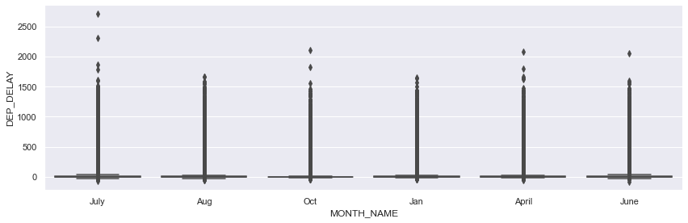

```python
sns.catplot(x = 'MONTH_NAME', y = 'DEP_DELAY', kind="box", data = df_raw, height=4, aspect=3)
```

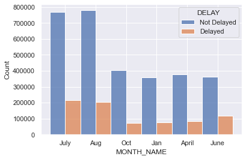

```python
sns.histplot(x='MONTH_NAME', data = df_raw, hue='DELAY', multiple="dodge", binwidth=1)
```

Looks like June is not only the month with more delay flights it's also the month with the longer mean of delays, but there are not significant differences. So it seems that there is not correlation between the Delay and the Month.

##### Weekday

```python
# Create a new variable to convert the weekdays to a string
dict_weekday = {0:'Mon', 1:'Tue', 2:'Wed', 3:'Thu', 4:'Fri', 5:'Sat', 6:'Sun'}
df_raw['WEEKDAY_NAME'] = df_raw['WEEKDAY'].map(dict_weekday)
```

```python
df_weekday_delays = df_raw[['WEEKDAY_NAME','DEP_DELAY']].groupby('WEEKDAY_NAME').mean()
df_weekday_delays['TOTAL_NUM_FLIGHTS'] = df_raw[['WEEKDAY_NAME','DEP_DELAY']].groupby('WEEKDAY_NAME').size()
df_weekday_delays['PERCENTAGE_DELAYED_FLIGHTS'] = round(df_raw[df_raw['DELAY']=='Delayed'][['WEEKDAY_NAME','DEP_DELAY']].groupby('WEEKDAY_NAME').size()/df_weekday_delays['TOTAL_NUM_FLIGHTS']*100,2)

df_weekday_delays.reset_index(inplace=True)
df_weekday_delays.head(10)
```

|  | WEEKDAY_NAME | DEP_DELAY | TOTAL_NUM_FLIGHTS | PERCENTAGE_DELAYED_FLIGHTS |
| --- | --- | --- | --- | --- |
| 0 | Fri | 12.926296 | 550621 | 21.01 |
| 1 | Mon | 13.150148 | 582545 | 21.17 |
| 2 | Sat | 11.043383 | 449046 | 18.43 |
| 3 | Sun | 13.214038 | 524939 | 20.99 |
| 4 | Thu | 13.524244 | 561805 | 21.15 |
| 5 | Tue | 11.315198 | 581438 | 19.11 |
| 6 | Wed | 10.483495 | 567447 | 18.54 |

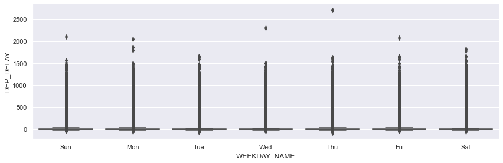

```python
sns.catplot(x = 'WEEKDAY_NAME', y = 'DEP_DELAY', kind="box", data = df_raw, height=4, aspect=3)
```

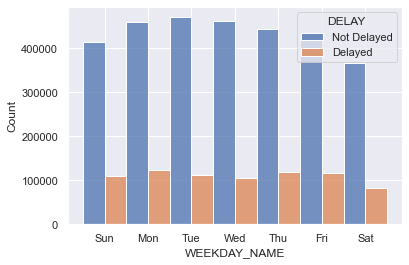

```python
sns.histplot(x='WEEKDAY_NAME', data = df_raw, hue='DELAY', multiple="dodge", binwidth=1)
```

Wednesdays, Saturdays and Tuesdays are the weekdays with both less number of delayed flights and lower mean of the delay time while Mondays, Fridays, Thursdays and Sundays show more delayed flights and higher mean of the delay time.

Looks like the weekday may have some impact but the differences are really small.

##### Number Flights per Airport

Get the mean of the delay and the percentage of the delayed flights per airport and compare it with the total number of flights.

```python
df_num_flights_airport = df_raw[['ORIGIN','DEP_DELAY']].groupby('ORIGIN').mean()
df_num_flights_airport['TOTAL_NUM_FLIGHTS'] = df_raw[['ORIGIN','DEP_DELAY']].groupby('ORIGIN').size()
df_num_flights_airport['PERCENTAGE_DELAYED_FLIGHTS'] = round(df_raw[df_raw['DELAY']=='Delayed'][['ORIGIN','DEP_DELAY']].groupby('ORIGIN').size()/df_num_flights_airport['TOTAL_NUM_FLIGHTS']*100,2)

df_num_flights_airport.reset_index(inplace=True)
df_num_flights_airport.sort_values(['DEP_DELAY'], ascending = False, inplace = True)
df_num_flights_airport.head(20)
```

|  | ORIGIN | DEP_DELAY | TOTAL_NUM_FLIGHTS | PERCENTAGE_DELAYED_FLIGHTS |
| --- | --- | --- | --- | --- |
| 296 | SWF | 33.985854 | 919 | 32.75 |
| 226 | OTH | 32.800712 | 281 | 30.25 |
| 142 | HYA | 32.212766 | 141 | 36.17 |
| 219 | OGS | 30.973856 | 153 | 23.53 |
| 5 | ACK | 29.148122 | 1411 | 28.92 |
| 183 | LWB | 27.754274 | 468 | 29.27 |
| 204 | MMH | 27.494444 | 180 | 29.44 |
| 191 | MEI | 27.145455 | 715 | 28.81 |
| 225 | ORH | 25.505391 | 742 | 29.92 |
| 310 | UIN | 25.098121 | 479 | 25.26 |
| 216 | OAJ | 24.405063 | 158 | 19.62 |
| 161 | JMS | 24.073132 | 629 | 17.81 |
| 283 | SLN | 23.219355 | 620 | 24.19 |
| 38 | BQN | 22.798060 | 1134 | 32.89 |
| 164 | KTN | 22.317241 | 145 | 23.45 |
| 166 | LAR | 22.294404 | 411 | 18.73 |
| 18 | ATY | 22.233645 | 214 | 17.76 |
| 100 | EWR | 21.933736 | 73328 | 27.83 |
| 137 | HPN | 21.451678 | 4470 | 25.10 |
| 88 | DVL | 21.230198 | 404 | 14.11 |

```python
df_num_flights_airport.sort_values(['PERCENTAGE_DELAYED_FLIGHTS'], ascending = False, inplace = True)
df_num_flights_airport.head(20)
```

|  | ORIGIN | DEP_DELAY | TOTAL_NUM_FLIGHTS | PERCENTAGE_DELAYED_FLIGHTS |
| --- | --- | --- | --- | --- |
| 142 | HYA | 32.212766 | 141 | 36.17 |
| 38 | BQN | 22.798060 | 1134 | 32.89 |
| 296 | SWF | 33.985854 | 919 | 32.75 |
| 226 | OTH | 32.800712 | 281 | 30.25 |
| 225 | ORH | 25.505391 | 742 | 29.92 |
| 204 | MMH | 27.494444 | 180 | 29.44 |
| 190 | MDW | 15.387408 | 57260 | 29.38 |
| 183 | LWB | 27.754274 | 468 | 29.27 |
| 244 | PSE | 19.180723 | 581 | 29.26 |
| 140 | HTS | 13.920354 | 113 | 29.20 |
| 5 | ACK | 29.148122 | 1411 | 28.92 |
| 191 | MEI | 27.145455 | 715 | 28.81 |
| 100 | EWR | 21.933736 | 73328 | 27.83 |
| 136 | HOU | 13.480263 | 38379 | 26.58 |
| 53 | CHO | 19.988554 | 1660 | 26.33 |
| 214 | MVY | 20.244186 | 688 | 26.02 |
| 108 | FLL | 17.529677 | 47546 | 25.60 |
| 310 | UIN | 25.098121 | 479 | 25.26 |
| 137 | HPN | 21.451678 | 4470 | 25.10 |
| 76 | DAL | 13.085679 | 47456 | 24.99 |

```python
df_num_flights_airport.sort_values(['TOTAL_NUM_FLIGHTS'], ascending = False, inplace = True)
df_num_flights_airport.head(20)
```

|  | ORIGIN | DEP_DELAY | TOTAL_NUM_FLIGHTS | PERCENTAGE_DELAYED_FLIGHTS |
| --- | --- | --- | --- | --- |
| 16 | ATL | 10.966496 | 231613 | 19.02 |
| 223 | ORD | 16.081264 | 206290 | 24.44 |
| 81 | DFW | 14.168917 | 158409 | 23.74 |
| 80 | DEN | 13.985279 | 148085 | 22.25 |
| 169 | LAX | 10.475353 | 127379 | 19.18 |
| 273 | SFO | 12.449279 | 101881 | 21.26 |
| 211 | MSP | 9.168850 | 99165 | 15.26 |
| 234 | PHX | 10.076134 | 98116 | 19.45 |
| 35 | BOS | 15.791017 | 90366 | 22.97 |
| 176 | LGA | 17.800444 | 89549 | 23.89 |
| 60 | CLT | 14.961494 | 85961 | 23.75 |
| 87 | DTW | 11.146863 | 85379 | 17.41 |
| 167 | LAS | 11.505427 | 81446 | 21.40 |
| 282 | SLC | 7.461559 | 75869 | 13.90 |
| 100 | EWR | 21.933736 | 73328 | 27.83 |
| 188 | MCO | 17.821129 | 72840 | 24.79 |
| 159 | JFK | 17.002098 | 67681 | 22.71 |
| 79 | DCA | 10.998864 | 66908 | 18.11 |
| 145 | IAH | 13.860867 | 65937 | 21.05 |
| 233 | PHL | 12.443373 | 60545 | 20.24 |

##### Carriers

```python
df_carrier_delays = df_raw[['OP_UNIQUE_CARRIER','DEP_DELAY']].groupby('OP_UNIQUE_CARRIER').mean()
df_carrier_delays['TOTAL_NUM_FLIGHTS'] = df_raw[['OP_UNIQUE_CARRIER','DEP_DELAY']].groupby('OP_UNIQUE_CARRIER').size()
df_carrier_delays['PERCENTAGE_DELAYED_FLIGHTS'] = round(df_raw[df_raw['DELAY']=='Delayed'][['OP_UNIQUE_CARRIER','DEP_DELAY']].groupby('OP_UNIQUE_CARRIER').size()/df_carrier_delays['TOTAL_NUM_FLIGHTS']*100,2)

df_carrier_delays.reset_index(inplace=True)
df_carrier_delays.head(10)
```

|  | OP_UNIQUE_CARRIER | DEP_DELAY | TOTAL_NUM_FLIGHTS | PERCENTAGE_DELAYED_FLIGHTS |
| --- | --- | --- | --- | --- |
| 0 | AA | 13.950567 | 622262 | 22.28 |
| 1 | B6 | 20.453461 | 199777 | 28.23 |
| 2 | DL | 9.775121 | 680299 | 15.83 |
| 3 | MQ | 9.721797 | 209139 | 18.97 |
| 4 | OO | 12.074660 | 551876 | 17.70 |
| 5 | UA | 14.860020 | 432290 | 21.20 |
| 6 | WN | 11.023171 | 909337 | 21.68 |
| 7 | YX | 10.513504 | 212861 | 17.93 |

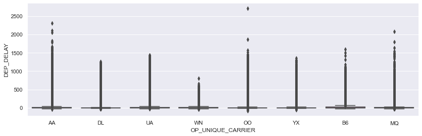

```python
sns.catplot(x = 'OP_UNIQUE_CARRIER', y = 'DEP_DELAY', kind="box", data = df_raw, height=4, aspect=3)
```

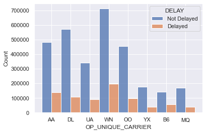

```python
sns.histplot(x='OP_UNIQUE_CARRIER', data = df_raw, hue='DELAY', multiple="dodge", binwidth=1)
```

There are clearly carriers that tend to have:

- Carrier B6 clearly shows a much higher percentage of delayed flights and also bigger mean of delay time.
- Carriers DL even though the number of flights is quite big, the percentage and mean of time for delayed flights is very low. Carrier MQ has similar values but wiht much less amount of flights.
- It's also remarkable the carrier WN because the percentage of delayed flight is significance but the mean of delay time is low, meaning that even thopigh there are many delays compare to other carriers, the delay time doesn't tend to be big.

Based on the results, the carriers seems to be relevant for this analysis

##### Departure Time

```python
df_departure_delays = df_raw[['DEP_TIME','DEP_DELAY']].groupby('DEP_TIME').mean()
df_departure_delays['TOTAL_NUM_FLIGHTS'] = df_raw[['DEP_TIME','DEP_DELAY']].groupby('DEP_TIME').size()
df_departure_delays['PERCENTAGE_DELAYED_FLIGHTS'] = round(df_raw[df_raw['DELAY']=='Delayed'][['DEP_TIME','DEP_DELAY']].groupby('DEP_TIME').size()/df_departure_delays['TOTAL_NUM_FLIGHTS']*100,2)

df_departure_delays.reset_index(inplace=True)
df_departure_delays.sort_values(['DEP_DELAY'], ascending = False, inplace = True)
df_departure_delays.head(24)
```

|  | DEP_TIME | DEP_DELAY | TOTAL_NUM_FLIGHTS | PERCENTAGE_DELAYED_FLIGHTS |
| --- | --- | --- | --- | --- |
| 2 | 2 | 24.245734 | 879 | 34.13 |
| 19 | 19 | 21.892008 | 203025 | 31.89 |
| 18 | 18 | 21.151897 | 215580 | 30.56 |
| 20 | 20 | 20.322572 | 189759 | 30.53 |
| 21 | 21 | 19.778303 | 117981 | 31.33 |
| 17 | 17 | 19.620628 | 241494 | 28.49 |
| 3 | 3 | 17.859241 | 817 | 27.17 |
| 16 | 16 | 17.665932 | 214926 | 26.73 |
| 22 | 22 | 17.504687 | 109985 | 28.48 |
| 15 | 15 | 16.020141 | 232060 | 24.71 |
| 23 | 23 | 15.755022 | 27329 | 25.35 |
| 1 | 1 | 15.668661 | 2674 | 22.55 |
| 14 | 14 | 14.855329 | 216554 | 23.30 |
| 4 | 4 | 12.781095 | 402 | 21.89 |
| 13 | 13 | 12.105960 | 215666 | 20.58 |
| 12 | 12 | 10.474236 | 232806 | 18.25 |
| 0 | 0 | 9.566329 | 7591 | 18.86 |
| 11 | 11 | 9.191057 | 234653 | 16.80 |
| 10 | 10 | 7.335543 | 234071 | 14.93 |
| 9 | 9 | 6.334962 | 220079 | 13.26 |
| 8 | 8 | 4.952448 | 261250 | 10.77 |
| 7 | 7 | 4.027397 | 256820 | 9.02 |
| 5 | 5 | 2.569996 | 92320 | 6.20 |
| 6 | 6 | 2.564025 | 289120 | 6.63 |

Based on the number of total flights, looks like first early morning flighst are scheduled after 5 AM and can be seen as from 6 AM till 7 PM the delay time and the percentage of delayed flights increase, so it may also be relevant.

##### Correlation

First, let's clean the data to prepare it for correlation calculation

```python
df_raw.head()
```

|  | FL_DATE | OP_UNIQUE_CARRIER | OP_CARRIER_FL_NUM | ORIGIN | CRS_DEP_TIME | DEP_DELAY | CRS_ARR_TIME | CRS_ELAPSED_TIME | DISTANCE | MONTH | WEEKDAY | DAY | NUMBER_FLIGHTS_AIRPORT | DEP_TIME | NUMBER_FLIGHTS_AIRPORT_HOUR | DELAY | MONTH_NAME | WEEKDAY_NAME |
| --- | --- | --- | --- | --- | --- | --- | --- | --- | --- | --- | --- | --- | --- | --- | --- | --- | --- | --- |
| 0 | 2018-07-01 | AA | 1664 | DEN | 3 | -7.0 | 536 | 213.0 | 1558.0 | 7 | 6 | 1 | 594 | 0 | 2 | Not Delayed | July | Sun |
| 1 | 2018-07-01 | DL | 2575 | DEN | 55 | -8.0 | 544 | 169.0 | 1199.0 | 7 | 6 | 1 | 594 | 0 | 2 | Not Delayed | July | Sun |
| 2 | 2018-07-01 | AA | 1654 | DEN | 123 | -8.0 | 629 | 186.0 | 1337.0 | 7 | 6 | 1 | 594 | 1 | 1 | Not Delayed | July | Sun |
| 3 | 2018-07-01 | AA | 1067 | DEN | 503 | -1.0 | 800 | 117.0 | 641.0 | 7 | 6 | 1 | 594 | 5 | 6 | Not Delayed | July | Sun |
| 4 | 2018-07-01 | UA | 1192 | DEN | 530 | -1.0 | 847 | 137.0 | 862.0 | 7 | 6 | 1 | 594 | 5 | 6 | Not Delayed | July | Sun |

The following features are already not needed:

- CRS_DEP_TIME
- CRS_ARR_TIME
- CRS_ELAPSED_TIME
- DAY
- MONTH_NAME
- WEEKDAY_NAME

Following feature need to be converted into numerical features:

- OP_UNIQUE_CARRIER
- ORIGIN
- DELAY

```python
df_raw.drop(['CRS_DEP_TIME', 'CRS_ARR_TIME', 'CRS_ELAPSED_TIME', 'MONTH_NAME',
             'DAY', 'WEEKDAY_NAME'], axis = 1, inplace= True)
df_with_delays.drop(['CRS_DEP_TIME', 'CRS_ARR_TIME', 'CRS_ELAPSED_TIME'], axis = 1, inplace= True)
```

Let's encode the variables needed to be converted to numeric:

```python
le= LabelEncoder()

df_raw['OP_UNIQUE_CARRIER'] = le.fit_transform(df_raw['OP_UNIQUE_CARRIER'])
df_raw['ORIGIN'] = le.fit_transform(df_raw['ORIGIN'])
df_raw['DELAY'] = le.fit_transform(df_raw['DELAY'])

df_with_delays['OP_UNIQUE_CARRIER'] = le.fit_transform(df_with_delays['OP_UNIQUE_CARRIER'])
df_with_delays['ORIGIN'] = le.fit_transform(df_with_delays['ORIGIN'])
df_with_delays['DELAY'] = le.fit_transform(df_with_delays['DELAY'])
```

Now, correlation can be calculated:

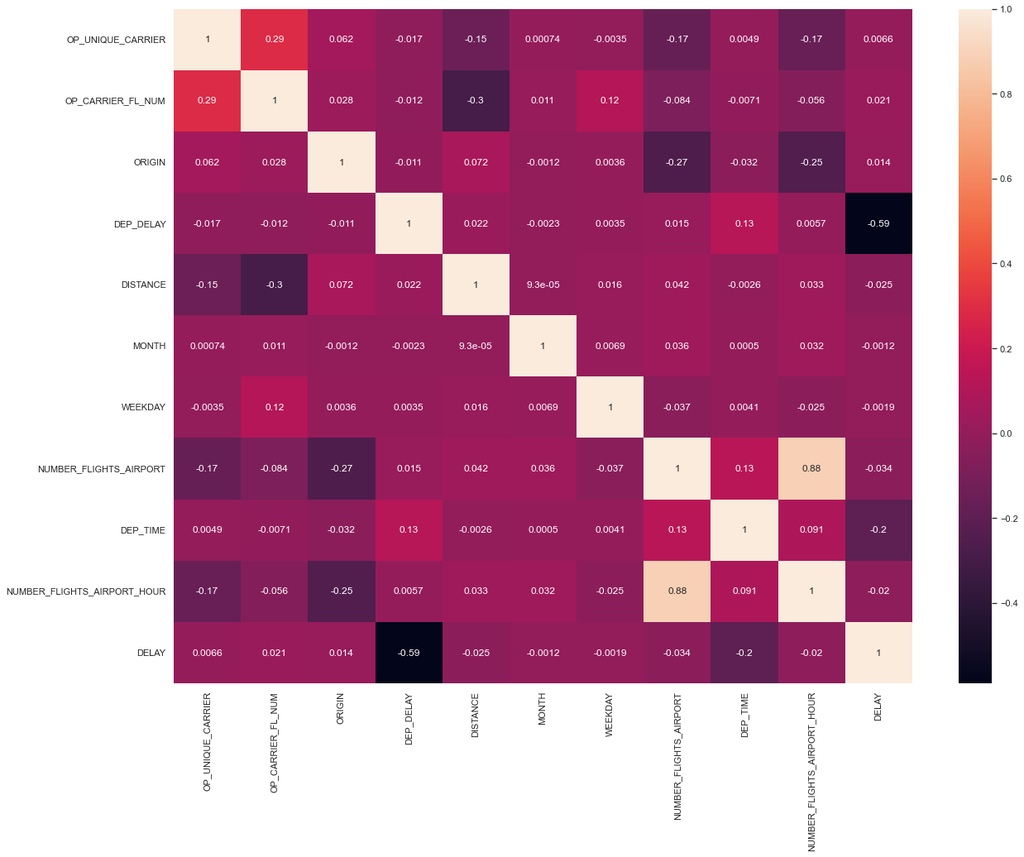

```python
# Excluding WEATHER_DELAY, LATE_AIRCRAFT_DELAY and SECURITY_DELAY features
corrMatrix = df_raw.corr()
plt.subplots(figsize=(20,15))
sns.heatmap(corrMatrix, annot=True)
plt.show()
```

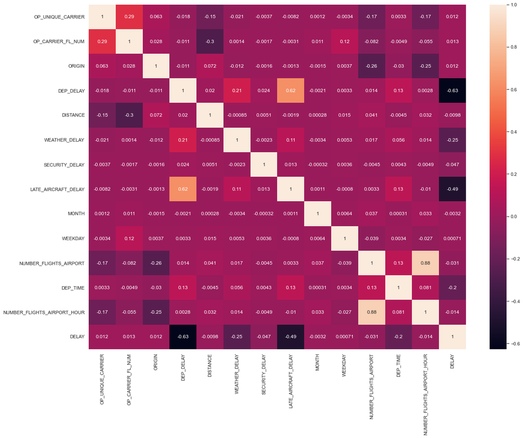

```python
# Including WEATHER_DELAY, LATE_AIRCRAFT_DELAY and SECURITY_DELAY features
corrMatrix = df_with_delays.corr()
plt.subplots(figsize=(20,15))
sns.heatmap(corrMatrix, annot=True)
plt.show()
```

We can see as the weather delay and late aircraft delay features are very relevant. The departure time seems to be also correlated while the least correlated features are the month and the weekday, even though that we observed some differences in the graphs, the results were very similar so it may be hard to find a pattern. The rest of the features don't show a high correlation value either.

### Data Preparation II

Let's remove the features which won't be used:

- Feature DELAY should be removes as was created for EDA section
- MONTH can also be deleted due to the fact that results were very similar, correlation very low and we don't have data from every month.

```python
df_raw.drop(['DELAY', 'MONTH'], axis = 1, inplace= True)
df_with_delays.drop(['DELAY', 'MONTH'], axis = 1, inplace= True)
```

### Machine Learning

Since the data is ready, first step is to split data into train and test datasets:

```python
X_train = df_with_delays[df_with_delays['FL_DATE']<datetime.datetime(year=2019,month=7,day=1)].drop(['FL_DATE',
                                                                                                     'DEP_DELAY'],axis=1).values
y_train = df_with_delays[df_with_delays['FL_DATE']<datetime.datetime(year=2019,month=7,day=1)]['DEP_DELAY'].values

X_test = df_with_delays[df_with_delays['FL_DATE']>datetime.datetime(year=2019,month=6,day=30)].drop(['FL_DATE',
                                                                                                  'DEP_DELAY'],axis=1).values
y_test = df_with_delays[df_with_delays['FL_DATE']>datetime.datetime(year=2019,month=6,day=30)]['DEP_DELAY'].values
```

```python
print("Percentage of test/validation data is {}%".format(round(X_test.shape[0]/df_with_delays.shape[0]*100)))
```

```
Percentage of test/validation data is 26%
```

We are going to evaluate the following algorithms with several sets of parameters:

- SGD Regressor
- Random Forest
- Decision Tree

```python
def models_and_parameters_definition():
    """
    Auxiliary function to define the models to try and the grid parameter search for
    cross validation
    :return: dict of {'model':'gs_model'}
    """
    sgdr = Pipeline([('stds', StandardScaler()), ('sgdr', SGDRegressor())])
    params_sgdr = {'sgdr__alpha': [0.00001, 0.0001, 0.001]}
    gs_sgdr = GridSearchCV(sgdr,
                          params_sgdr,
                          cv=3,
                          scoring="neg_mean_squared_error",
                          verbose = 10)

    rf = RandomForestRegressor()
    params_rf = {'max_depth': [10, 30]} # Maximum number of levels in tree
    gs_rf = GridSearchCV(rf,
                         params_rf,
                         cv=3,
                         scoring="neg_mean_squared_error",
                         verbose = 10)


    dt = DecisionTreeRegressor()
    params_dt = {'max_depth': [10, 30, 50, 100]} # Maximum number of levels in tree
    gs_dt = GridSearchCV(dt,
                         params_dt,
                         cv=3,
                         scoring="neg_mean_squared_error",
                         verbose = 10)

    grid_search_models = {"gs_sgdr": gs_sgdr,
                          "gs_rf": gs_rf,
                          "gs_dt": gs_dt}
    return grid_search_models
```

```python
def select_best_model(X_train, y_train, grid_search_models=False):
    """
    Function to select the best model with the best parameters
    :param grid_search_models: dictionary with all gridSearch we want to run. If it is not given to the function,
                              it runs models_and_parameters_definition function, where there are some models defined
    :param X_train: dataset of features to train the model
    :param y_train: categories to train the model
    :return:
    """
    if not grid_search_models:
        grid_search_models = models_and_parameters_definition()

    for name, grid_search in grid_search_models.items():
        print("Doing Grid Search of %s..." % name)
        grid_search.fit(X_train, y_train)

    best_score_each_gridsearch = [(model_name, grid_search.best_score_, grid_search.best_params_,
                                       str(grid_search.best_estimator_))
                                      for model_name, grid_search in grid_search_models.items()]

    df_best_score_each_gridsearch = pd.DataFrame(best_score_each_gridsearch,
                                                     columns=["gridSearchCV", "best_score",
                                                              "best_params", "best_estimator"])

    df_sorted_best_score_each_gridsearch = (df_best_score_each_gridsearch.sort_values(by="best_score",
                                                                                      ascending=False))



    model_summary = pd.DataFrame(df_sorted_best_score_each_gridsearch)
    best_model_name = model_summary['gridSearchCV'].values[0]
    best_model = grid_search_models.get(best_model_name)
    return best_model, model_summary, grid_search_models
```

Models can be trained and we will get the best model, the model summary which includes the parameters and score of the best model from each algorithm, and the estimator.

```python
best_model, model_summary, grid_search_models = select_best_model(X_train, y_train)
```

```
Doing Grid Search of gs_sgdr...
Fitting 3 folds for each of 3 candidates, totalling 9 fits
[CV 1/3; 1/3] START sgdr__alpha=1e-05...........................................
[CV 1/3; 1/3] END ........sgdr__alpha=1e-05;, score=-1380.753 total time=  14.2s
[CV 2/3; 1/3] START sgdr__alpha=1e-05...........................................
[CV 2/3; 1/3] END ........sgdr__alpha=1e-05;, score=-1220.119 total time=  13.2s
[CV 3/3; 1/3] START sgdr__alpha=1e-05...........................................
[CV 3/3; 1/3] END ........sgdr__alpha=1e-05;, score=-1572.797 total time=  16.7s
[CV 1/3; 2/3] START sgdr__alpha=0.0001..........................................
[CV 1/3; 2/3] END .......sgdr__alpha=0.0001;, score=-1382.098 total time=  20.9s
[CV 2/3; 2/3] START sgdr__alpha=0.0001..........................................
[CV 2/3; 2/3] END .......sgdr__alpha=0.0001;, score=-1222.357 total time=  17.1s
[CV 3/3; 2/3] START sgdr__alpha=0.0001..........................................
[CV 3/3; 2/3] END .......sgdr__alpha=0.0001;, score=-1572.707 total time=  25.4s
[CV 1/3; 3/3] START sgdr__alpha=0.001...........................................
[CV 1/3; 3/3] END ........sgdr__alpha=0.001;, score=-1382.936 total time=  32.3s
[CV 2/3; 3/3] START sgdr__alpha=0.001...........................................
[CV 2/3; 3/3] END ........sgdr__alpha=0.001;, score=-1221.897 total time=   9.3s
[CV 3/3; 3/3] START sgdr__alpha=0.001...........................................
[CV 3/3; 3/3] END ........sgdr__alpha=0.001;, score=-1573.396 total time=  12.3s
Doing Grid Search of gs_rf...
Fitting 3 folds for each of 2 candidates, totalling 6 fits
[CV 1/3; 1/2] START max_depth=10................................................
[CV 1/3; 1/2] END .............max_depth=10;, score=-1357.567 total time= 9.1min
[CV 2/3; 1/2] START max_depth=10................................................
[CV 2/3; 1/2] END .............max_depth=10;, score=-1181.140 total time= 9.1min
[CV 3/3; 1/2] START max_depth=10................................................
[CV 3/3; 1/2] END .............max_depth=10;, score=-1534.264 total time= 9.0min
[CV 1/3; 2/2] START max_depth=30................................................
[CV 1/3; 2/2] END .............max_depth=30;, score=-1527.547 total time=17.0min
[CV 2/3; 2/2] START max_depth=30................................................
[CV 2/3; 2/2] END .............max_depth=30;, score=-1394.822 total time=16.8min
[CV 3/3; 2/2] START max_depth=30................................................
[CV 3/3; 2/2] END .............max_depth=30;, score=-1681.233 total time=18.3min
Doing Grid Search of gs_dt...
Fitting 3 folds for each of 4 candidates, totalling 12 fits
[CV 1/3; 1/4] START max_depth=10................................................
[CV 1/3; 1/4] END .............max_depth=10;, score=-1436.484 total time=   7.8s
[CV 2/3; 1/4] START max_depth=10................................................
[CV 2/3; 1/4] END .............max_depth=10;, score=-1233.701 total time=   7.8s
[CV 3/3; 1/4] START max_depth=10................................................
[CV 3/3; 1/4] END .............max_depth=10;, score=-1604.960 total time=   7.2s
[CV 1/3; 2/4] START max_depth=30................................................
[CV 1/3; 2/4] END .............max_depth=30;, score=-3150.517 total time=  14.5s
[CV 2/3; 2/4] START max_depth=30................................................
[CV 2/3; 2/4] END .............max_depth=30;, score=-3235.528 total time=  14.0s
[CV 3/3; 2/4] START max_depth=30................................................
[CV 3/3; 2/4] END .............max_depth=30;, score=-3394.539 total time=  13.5s
[CV 1/3; 3/4] START max_depth=50................................................
[CV 1/3; 3/4] END .............max_depth=50;, score=-3274.373 total time=  16.4s
[CV 2/3; 3/4] START max_depth=50................................................
[CV 2/3; 3/4] END .............max_depth=50;, score=-3415.792 total time=  15.0s
[CV 3/3; 3/4] START max_depth=50................................................
[CV 3/3; 3/4] END .............max_depth=50;, score=-3572.158 total time=  15.9s
[CV 1/3; 4/4] START max_depth=100...............................................
[CV 1/3; 4/4] END ............max_depth=100;, score=-3352.632 total time=  16.2s
[CV 2/3; 4/4] START max_depth=100...............................................
[CV 2/3; 4/4] END ............max_depth=100;, score=-3437.045 total time=  15.9s
[CV 3/3; 4/4] START max_depth=100...............................................
[CV 3/3; 4/4] END ............max_depth=100;, score=-3582.965 total time=  15.0s
```

```python
model_summary
```

|  | gridSearchCV | best_score | best_params | best_estimator |
| --- | --- | --- | --- | --- |
| 1 | gs_rf | -1357.657072 | {'max_depth': 10} | RandomForestRegressor(max_depth=10) |
| 0 | gs_sgdr | -1391.223404 | {'sgdr__alpha': 1e-05} | Pipeline(steps=[('stds', StandardScaler()),\n ... |
| 2 | gs_dt | -1425.048429 | {'max_depth': 10} | DecisionTreeRegressor(max_depth=10) |

The best model is RF with a max depth set to 10

Next step is to evaluate this model with the test set.

```python
def model_performance_report(X, y, model):
    """
    Given a set of data and its labels returns a classification report
    :param X: dataset with features
    :param y: dataset with the label to classify
    :param model: classification model selected
    :return:
    """
    y_pred = model.predict(X)
    mae = mean_absolute_error(y, y_pred)
    mse = mean_squared_error(y, y_pred)
    r2 = r2_score(y, y_pred)
    return mae, mse, r2
```

```python
mae, mse, r2 = model_performance_report(X_test, y_test, best_model)
```

```python
print('Value of MAE is: {}\nValue of MSE is: {}\nValue of R2 is: {}'.format(mae, mse, r2))
```

```
Value of MAE is: 12.892488332041951
Value of MSE is: 1701.772762213547
Value of R2 is: 0.4144645877590788
```

It's important to highlight for this section that due to the high time consuming that some algorithms takes, there is no focus on hypeparameter optimization since it will take too much time although it's known that would improve a lot the performance.

### Deep Learning

```python
scaler = StandardScaler()
X_train_dl = scaler.fit_transform(X_train)
X_test_dl = scaler.fit_transform(X_test)
```

```python
def build_model():
    model = Sequential([
    Dense(500, activation='relu', input_shape=[X_train_dl.shape[1]]),
    Dense(100, activation='relu'),
    Dense(50, activation='relu'),
    Dense(1)])

    model.compile(loss='mse',
                  optimizer='adam',
                  metrics=['mae', 'mse'])
    return model
```

```python
model = build_model()
```

```python
history = model.fit(X_train_dl, y_train, batch_size=32, epochs=50, verbose = 1)
```

```python
test_predictions = model.predict(X_test_dl).flatten()
```

```python
mae_dl = mean_absolute_error(y_test, test_predictions)
mse_dl = mean_squared_error(y_test, test_predictions)
r2_dl = r2_score(y_test, test_predictions)
```

```python
print('Value of MAE is: {}\nValue of MSE is: {}\nValue of R2 is: {}'.format(mae_dl, mse_dl, r2_dl))
```

```
Value of MAE is: 12.773512363391875
Value of MSE is: 1699.2586538154997
Value of R2 is: 0.4153296265762204
```

Again, as for Machine Learning algorithms, no focus on hyperparameter optimization for same reason

### Conclusion

First of all, the performance for deep learning and the Random Forest is very similar, although the deep learning tehcnique could be modified to get better results with a better optimization but would take much more time.

The prediction could also be improved by:

- Collecting weather data for every record.
- Collecting the air traffic data for every record.
- Adding other relevant features as, for example, if there are passengers connecting from a previous flight.
- Getting data from every month so both month are weekday can be more relevant for the prediction and the bank holidays as New Year or Christmas can be also added.